# DATA 624 Homework 5

### Exercise 8.8.8

Recall your retail time series data (from Exercise 8 in Section 2.10).

```r
set.seed(123)
myseries <- aus_retail %>%
  filter(`Series ID` == sample(aus_retail$`Series ID`,1))
```

**a.** Why is multiplicative seasonality necessary for this series?

As observed previously with the data from gas production, we can observe that these data have an increasing trend, seasonality as well as variation. As discussed earlier, the Multiplicative method is preferred when the seasonal variations are changing proportional to the level of the series.

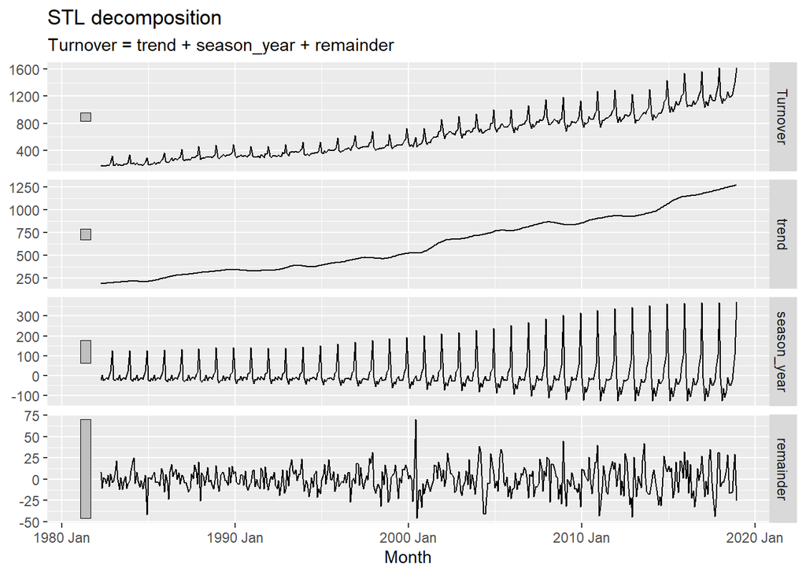

```r
#STL decomposition
dcmp3 <- myseries %>%
  model(stl = STL(Turnover))

components(dcmp3) %>% autoplot()
```

we can also compare below the Multipliatie and Additive methods and conclude that the Multiplicative method is better.

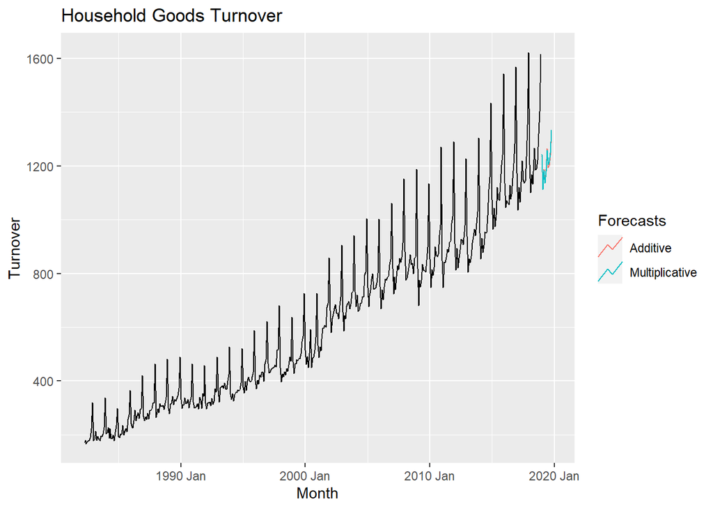

```r
fit5 <- myseries %>%
  model(
    "Additive" = ETS(Turnover ~ error('A') + trend('A') + season('A')),
    "Multiplicative" = ETS(Turnover ~ error('M') + trend('A') + season('M'))
  )

fc5 <- fit5 %>%
  forecast(h = 10)

fc5 %>% autoplot(myseries, level = NULL) +
  labs(title = "Household Goods Turnover") +
  guides(colour = guide_legend(title = "Forecasts"))
```

```r
accuracy(fit5)
```

```
## # A tibble: 2 x 12
##   State Industry .model .type      ME  RMSE   MAE    MPE  MAPE  MASE RMSSE  ACF1
##   <chr> <chr>    <chr>  <chr>   <dbl> <dbl> <dbl>  <dbl> <dbl> <dbl> <dbl> <dbl>
## 1 Vict~ Househo~ Addit~ Trai~ -0.0163  26.4  20.0 -0.336  4.04 0.517 0.529 0.244
## 2 Vict~ Househo~ Multi~ Trai~  2.13    24.3  18.3  0.125  3.40 0.473 0.488 0.316
```

**b.** Apply Holt-Winters’ multiplicative method to the data. Experiment with making the trend damped.

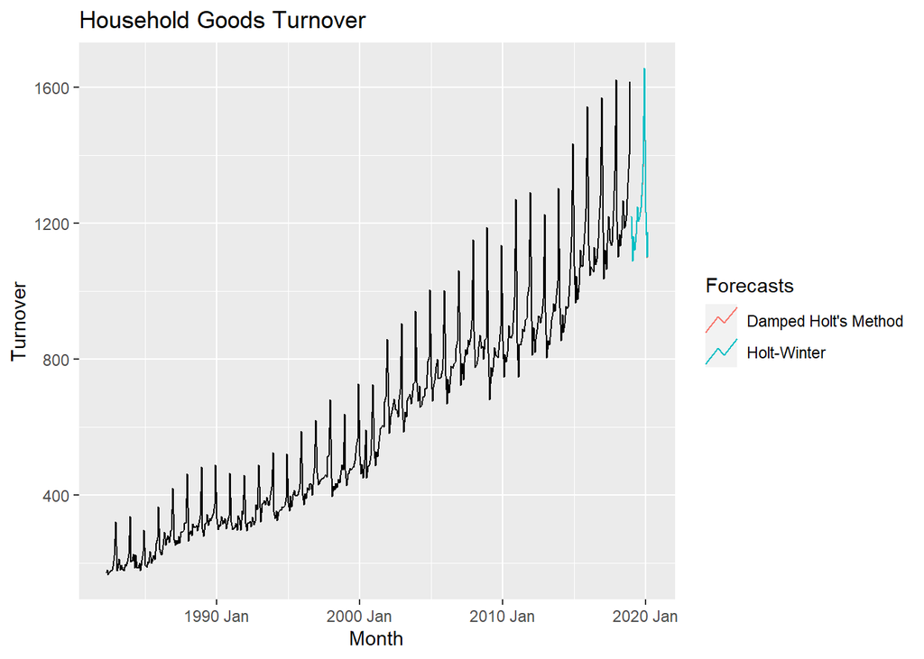

```r
fit6 <- myseries %>%
  model(
    "Holt-Winter" = ETS(Turnover ~ error('M') + trend('Ad') + season('M')),
    "Damped Holt's Method" = ETS(Turnover ~ error('A') + trend('Ad') + season('M'))
  )

fc6 <- fit6 %>%
  forecast(h = 15)

fc6 %>% autoplot(myseries, level = NULL) +
  labs(title = "Household Goods Turnover") +
  guides(colour = guide_legend(title = "Forecasts"))
```

**c.** Compare the RMSE of the one-step forecasts from the two methods. Which do you prefer?

```r
accuracy(fit6)
```

```
## # A tibble: 2 x 12
##   State    Industry .model .type    ME  RMSE   MAE   MPE  MAPE  MASE RMSSE   ACF1
##   <chr>    <chr>    <chr>  <chr> <dbl> <dbl> <dbl> <dbl> <dbl> <dbl> <dbl>  <dbl>
## 1 Victoria Househo~ Holt-~ Trai~  2.37  23.7  17.1 0.331  3.12 0.441 0.475 0.0862
## 2 Victoria Househo~ Dampe~ Trai~  2.35  23.6  16.9 0.258  3.16 0.436 0.472 0.0250
```

**d.** Check that the residuals from the best method look like white noise.

It seems that the residuals on the time plot show a slight increase in variability from the year 2000 and on. We can also observe that there is some correlation on the ACF of the residuals but the histogram seems to be close to normal.

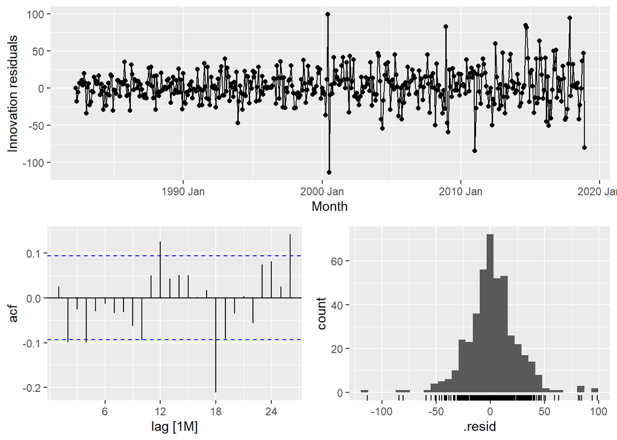

```r
best_fit <- myseries %>%
  model(
    "Damped Holt's Method" = ETS(Turnover ~ error('A') + trend('Ad') + season('M'))
  )

best_fc <- best_fit %>%
  forecast(h = 15)

best_fit %>% gg_tsresiduals()
```

**e.** Now find the test set RMSE, while training the model to the end of 2010. Can you beat the seasonal naïve approach from Exercise 7 in Section 5.11?

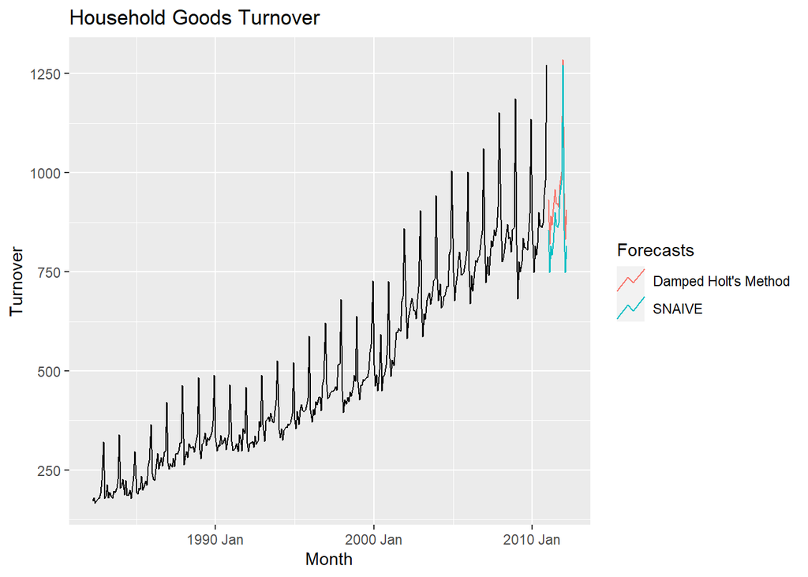

```r
myseries_train <- myseries %>%
  filter(year(Month) < 2011)

fit_train <- myseries_train %>%
  model(
    "SNAIVE" = SNAIVE(Turnover),
    "Damped Holt's Method" = ETS(Turnover ~ error('A') + trend('Ad') + season('M'))
  )

fc_train <- fit_train %>%
  forecast(h = 15)

fc_train %>% autoplot(myseries_train, level = NULL) +
  labs(title = "Household Goods Turnover") +
  guides(colour = guide_legend(title = "Forecasts"))
```

```r
fc_train %>% accuracy(myseries)
```

```
## # A tibble: 2 x 12
##   .model   State Industry  .type    ME  RMSE   MAE   MPE  MAPE  MASE RMSSE  ACF1
##   <chr>    <chr> <chr>     <chr> <dbl> <dbl> <dbl> <dbl> <dbl> <dbl> <dbl> <dbl>
## 1 Damped ~ Vict~ Househol~ Test  -28.2  41.8  33.6 -3.39  3.92 0.947 0.918 0.660
## 2 SNAIVE   Vict~ Househol~ Test   33.7  42.3  36.0  3.73  4.00 1.02  0.928 0.411
```

We can conclude from the above graph and accuracy metrics that the damped method is superior to the seasonal naive approach.

### Exercise 8.8.9

For the same retail data, try an STL decomposition applied to the Box-Cox transformed series, followed by ETS on the seasonally adjusted data. How does that compare with your best previous forecasts on the test set?

```r
#lambda for boxcox
lambda2 <- myseries_train %>%
  features(Turnover, features = guerrero) %>%
  pull(lambda_guerrero)
```

```r
#boxcox transformation
myseries_train_bx <- myseries_train
myseries_train_bx$Turnover <- box_cox(myseries_train$Turnover,lambda2)
```

As we can observe below, the Box-Cox transformation made the seasonality a lot more constant as well as the variability in the remainder.

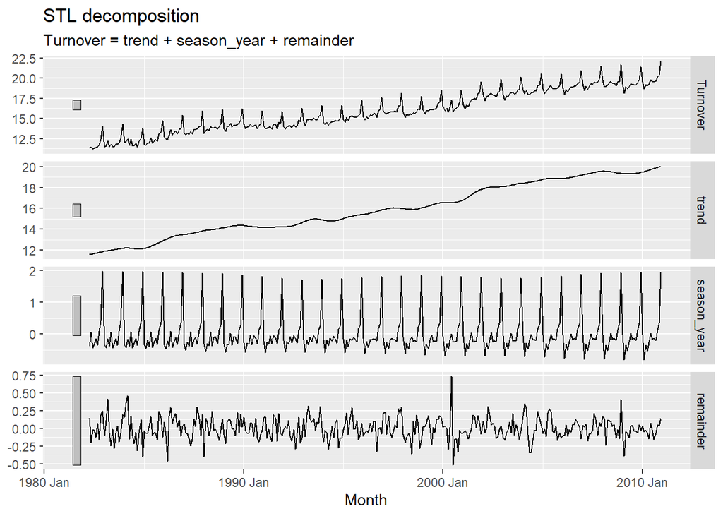

```r
#STL decomposition
dcmp4 <- myseries_train_bx %>%
  model(stl = STL(Turnover))

components(dcmp4) %>% autoplot()
```

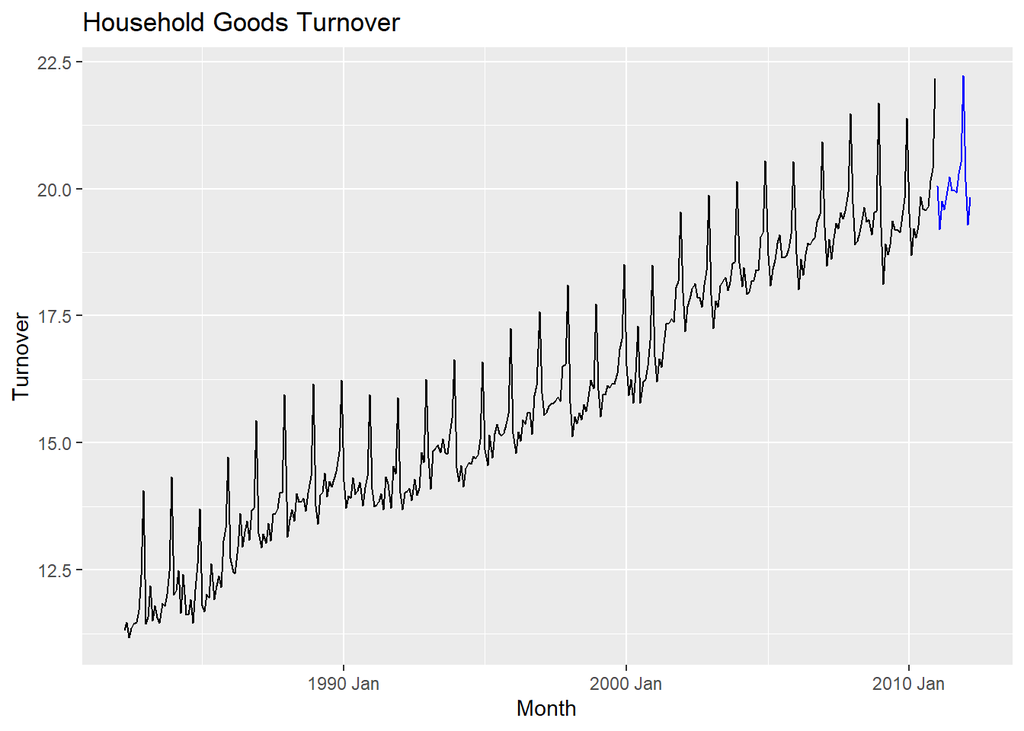

```r
fit_train2 <- myseries_train_bx %>%
  model(
    "Damped Holt's Method" = ETS(Turnover ~ error('A') + trend('Ad') + season('M'))
  )

fc_train2 <- fit_train2 %>%
  forecast(h = 15)

fc_train2 %>% autoplot(myseries_train_bx, level = NULL) +
  labs(title = "Household Goods Turnover") +
  guides(colour = guide_legend(title = "Forecasts"))
```

```r
accuracy(fit_train)
```

```
## # A tibble: 2 x 12
##   State    Industry .model .type    ME  RMSE   MAE   MPE  MAPE  MASE RMSSE    ACF1
##   <chr>    <chr>    <chr>  <chr> <dbl> <dbl> <dbl> <dbl> <dbl> <dbl> <dbl>   <dbl>
## 1 Victoria Househo~ SNAIVE Trai~ 25.1   45.6  35.4 5.05   7.29 1     1      0.695
## 2 Victoria Househo~ Dampe~ Trai~  2.12  20.3  14.8 0.315  3.33 0.417 0.445 -0.0345
```

```r
accuracy(fit_train2)
```

```
## # A tibble: 1 x 12
##   State    Industry    .model   .type     ME  RMSE   MAE   MPE  MAPE  MASE RMSSE
##   <chr>    <chr>       <chr>    <chr>  <dbl> <dbl> <dbl> <dbl> <dbl> <dbl> <dbl>
## 1 Victoria Household ~ Damped ~ Trai~ 0.0238 0.231 0.174 0.137  1.14 0.434 0.465
## # ... with 1 more variable: ACF1 <dbl>
```